# Python for Non-Programmers

## Operations on Sets

| Col1 | Col2 |
| --- | --- |
| set.add( n) | The add() function in python sets takes the value as an argument which we want to add to our set and adds the element in our set. one element at a time |
| set. remove ( m ) | The function deletes the specified element from the set and if the element is not present in the set, it does not return any error. |
| set. pop ( ) | pop() function doesn’t take any argument and it removes an arbitrary element from the set and also returns the deleted element. |
| set. clear( ) | The clear() function empties the set. It can also be used for dictionaries. |
| set.update( ) | The update() function in python sets can be used to add multiple values to the set at once. It takes an iterable like lists, set or tuple as an argument. |
| set.union ({4,5}) | Return a new set with all item from both sets |
| set.intersection({7,8}) | Return a set contains common item of both sets |
| set1.difference(set2) | Return the Set1 - Set2 |
| set1.symmetric_difference(set2) | return the elements those are not common in set1 and set2 |
| set1.issubset(set2) |  |

```python
c = {1,2,3}
c.add([1,2,3]) # we can't add list and dictionaries in a set
```

```
## Error in py_call_impl(callable, dots$args, dots$keywords): TypeError: unhashable type: 'list'
##
## Detailed traceback:
##   File "<string>", line 1, in <module>
```

```python
c.add((1,2,3))# we can add tuple
print(c)
```

```
## {1, 2, 3, (1, 2, 3)}
```

```python
print(len(c)) # prints the length of set c
```

```
## 4
```

```python
c.remove(2)  # removes 2 from  set c
print(c)
```

```
## {1, 3, (1, 2, 3)}
```

```python
print(c.pop()) # removes any arbitrary number from  set c and return the value
```

```
## 1
```

```python
print(c)
```

```
## {3, (1, 2, 3)}
```

```python
c.update({8,9})
print(c)
```

```
## {3, 8, 9, (1, 2, 3)}
```

## Exercise

1. The Swift, City and Civic have the following prices in thousands 2800, 3500, 6200 respectively. Create a dictionary `car_price_dict` where the keys are the car name and the price in thousands are the values.
2. You will need this dictionary for the next two questions: Dict= {‘SBP_ACT’: ‘1956’, ‘BCO’:‘1962’}

   In the Dict, what are the keys?
3. In the Dict, what are the values?
4. Use the dictionary find the price of the City.
5. Find the names of the cars from the dictionary using the method `keys()`
6. Find the prices of the cars from the dictionary using the method `values()`
7. Create a dictionary of Urdu words with values as their English translation. Provide user an option to look it up.
8. Consider the list `A = [1, 2, 2, 1]` and set `B = set([1, 2, 2, 1])`, does `sum(A) == sum(B)`?
9. Create a new set `C` that is the union of sets `A={1, 2, 3, 4}` and `B={3, 4, 5, 6}`.
10. Find out if `A` is a subset of `C.`
11. Write a program to add an element in a set.
12. Write a program to add **more than one element** in a set.
13. Write a program to remove items from a given set.
14. Write a program to create an intersection of set.
15. Write a program to create a union of sets.
16. Write a program to input 5 numbers from the user and display all the unique numbers
17. Can we have a set with elements 3 and ‘3’ ?
18. What is the type of s = { }?
19. What will be the length of set s:

    s = set(), s.add(1), s.add(1.0), s.add(‘1’)
20. Create a dictionary. Allow 4 users to enter their favorite Fruits as value , ans use their names as keys. Assume names are unique.
21. If names of 2 users are same in above problem, what will happen?
22. If fruit options of 2 users are same in above problem, what will happen?
23. Check if a set is a subset of another set using comparison operator and isubset() operator.
24. Write a Python program to print out a set containing all the colors from color1 which are not present in color2.

    `color1 = set(["White","Black", "Red"])`

    `color2 = set(["Red", "Green"]), Expected Output:{'Black','White'}`
25. Provide a use case for each of the following Python data structures: tuple, list, and dictionary. Explain why each use case is appropriate for each data structure as opposed to the others.

    List - A shopping list. The list type is appropriate, since it can be changed.

    Tuple - The first 7 prime numbers. A tuple is a suitable structure, because it is a immutable data type.

    Dictionary - A list of words and their meanings. Since a dictionary is made up by key-value pairs, the key would be the word and the value would assume it’s meaning.

    Set - A list of registered e-mails in a system. It’s a proper way to store them, for the e-mails must each be unique.
26. Ask the phone number from a user, and convert integers into strings like: 1 to one.
27. Creat a dictionary of animal names as keys and their pictures as values. Hint: to get picture/emoji’s press window+period(.)
28. Take input from user to show the picture of the animal. Also provide to look at the names of the animals in the dictionary.
29. If animal’s picture is not in the dictionary, provide the option to add the name and picture in the dictionary on run time.

# Conditional Expressions

Decision making is required when we want to execute a code only if a certain condition is satisfied. The if…elif…else statement is used in Python for decision making. If-else conditional statement is used in when a situation leads to **two conditions** and **one of them should hold true**.

## If else Statement Syntax

```python
x=1
if x==1:
    print("x is 1") # this is body of if or statement
#else:
 #   print("x is not 1") # this is body of elif
```

```
## x is 1
```

Here, the program evaluates the `test expression` and will execute statement(s) only if the test expression is `True`. If the test expression is `False`, the statement(s) is not executed.

In Python, the body of the `if` statement is indicated by the **indentation**. The body starts with an indentation and the first unindented line marks the end.

Remember: Python interprets non-zero values as `True`. `None` and `0` are interpreted as `False`.

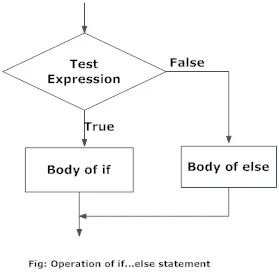

## Indentation

Python uses **indentation** for blocks, instead of curly braces. Both **tabs and spaces** are supported, but the standard indentation requires standard Python code to **use four spaces**. For example:

```python
x=1
if x==1:
    #indented four spaces
    print("x is 1")
else:
    print("x is not 1")
```

```
## x is 1
```

## If elif and else Statement

```python
x=-1
if x==1:
    #indented four spaces
    print("x is 1") # this is body of if or statement
elif x<0:
  print("x is less than zero")
else:
    print("x is not 1") # this is body of elif
```

```
## x is less than zero
```

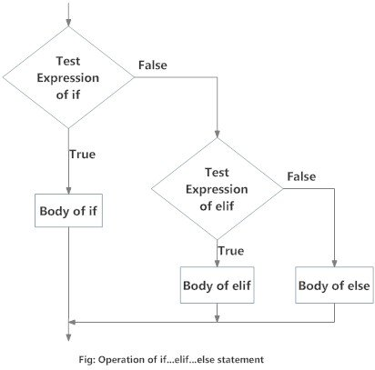

### Example

Write a program to print ‘Yes’ when the number entered by the user is greater than or equal to 25.

```python
#n = int(input(" Please enter the number: "))
n=32
if n>=25:
  print("Yes")
else:
  print("No")
```

```
## Yes
```

Write a program to check if a number entered by the user is positive or negative or zero and display an appropriate message.

```python
#n = int(input(" Please enter the number: "))
n = -4
if n>0:
  print("Number is +ve")
elif n==0:
  print("Number is zero")
else:
  print("Number is -ve")
```

```
## Number is -ve
```

we use if elif and else statement *if one of the statement is true*.

## Nested if statements

We can have a `if...elif...else` statement inside another `if...elif...else` statement. This is called **nesting** in computer programming.

Any number of these statements can be nested inside one another. Indentation is the only way to figure out the level of nesting. They can get confusing, so they must be avoided unless necessary.

Example: Write a program to check if a number entered by the user is positive or negative or zero and display an appropriate message using nested if statement.

```python
#n = int(input(" Please enter the number: "))
n = 3
if n>=0:
  if n==0:
    print("Number is zero")
  else:
    print("Number is +ve")
else:
  print("Number is -ve")
```

```
## Number is +ve
```

### Note:

- There can any number of elif statements.
- last else will be executed if all elif conditions/statements fails.

## Multiple If Conditions

### Example

Write a program to print largest number among four numbers entered by the user.

```python
n1 = 4 #n1 = int(input(" Enter the First Number : "))
n2 = 3 #n2 = int(input(" Enter the 2nd  Number : "))
n3 = 2 #n3 = int(input(" Enter the 3rd Number : "))
n4 = 1 #n4 = int(input(" Enter the 4th Number : "))

if n1>n2:
    f1 = n1
else:
   f1 = n2
if n3>n4:
   f2 = n3
else:
    f2 = n4
if f1>f2:
    print(f" The Largest Number is : {f1} ")
else:
    print(f" The Largest Number is : {f2} ")
```

```
##  The Largest Number is : 4
```

## Exercise

1. Write a program to check whether a user entered number is odd or even?
2. Take two numbers from user and print larger.
3. Take three numbers from user, and print the largest.
4. Write a program to check whether a user entered number is odd or even,valid only for first 10 natural numbers.
5. write a program to get the difference b/w a given number and 17, if number is greater than 17, return double the absolute difference.
6. Write a program to calculate the sum of three given numbers, if values are equal then return thrice of their sum.
7. Write a prog. to get a new string from a given string where “Is” has been added to the front. if the given string already begins with “Is” then return the string.
8. If Question mark ‘?’ is missing in above string, then also include the ‘?’ at the end.
9. Write a program to find out whether a given post is talking about “SBP” or not.
   1. Write a program to find out whether a student is fail or pass? if it require total 40% and at-least 33% in each subject to pass. Assume 3 subjects, input from the user and marks are out of 100.
10. Write a program to detect a spam (OSICO Spam detector), a spam comment is defined as a text containing following keywords:

    “make a lot of money”, “buy now”, “subscribe this”, “click this”. Write a program to detect these spams.
11. Write a program to calculate the grade of an officer from his numeric rating from the following scheme: greater than 4.5 implies A, greater than 3.5 implies B+, greater than 3 implies B and else C.
12. Write a program to find out the type of the variable Var1 = ——-. suppose 1+2j check whether it is int, float, str, bool, complex, tuple, dict, list, or unknown.
13. Write a Python program to sum of three given integers. However, if two values are equal sum will be zero.
14. Write a program to calculate the fare of a journey based on the following conditions, fare will be charged Rs. 15/km for first 100km, for next 200km it will be Rs.14/km, for next 200km it will be Rs.12/km and for distance above 500km, it will be charged Rs.11/km.
15. Write a routine to convert weight from Kg to pounds or pounds to kg.

# Loops

Loops are one of the most **powerful** and basic concepts in programming. A loop can contain a set of statements that keeps on executing until a **specific condition is reached**.

Programming languages provide us the **concept of loops** which helps us in executing some task *n number of times* where n can be any whole number. They are pretty **useful** and can be **applied** to various use cases.

There are two types of loops in Python.

## The “for” loop

For loop iterate over a given sequence (range, list, tuple, string etc.) or other iterable objects. Iterating over a sequence is called traversal. Flow chart of for loop is:

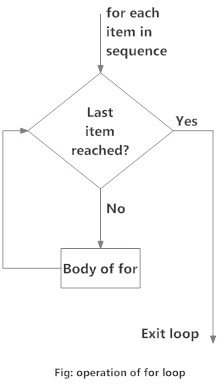

## Looping through String

Even strings are iterable objects, they contain a sequence of characters:

```python
for letter in 'string':
  print(letter)
```

```
## s
## t
## r
## i
## n
## g
```

## Looping through a List

```python
Banks = ['ABL', 'MCB', 'NBP']
for bank in Banks:
  print(bank)
```

```
## ABL
## MCB
## NBP
```

## How to Use Index

```python
Banks = ['ABL', 'MCB', 'NBP']
for i in range(3):
  print(i, Banks[i])
```

```
## 0 ABL
## 1 MCB
## 2 NBP
```

## Use of Enumerate for Indexing

```python
# Loop through the list and iterate on both index and element value

squares=['red', 'yellow', 'green', 'purple', 'blue']

for i, square in enumerate(squares):
    print(i, square)
```

```
## 0 red
## 1 yellow
## 2 green
## 3 purple
## 4 blue
```

We can change the elements in a list:

```python
# Use for loop to change the elements in list

squares = ['red', 'yellow', 'green', 'purple', 'blue']

for i in range(0, 5):
    print("Before square ", i, 'is',  squares[i])
    squares[i] = 'white'
    print("After square ", i, 'is',  squares[i])
```

```
## Before square  0 is red
## After square  0 is white
## Before square  1 is yellow
## After square  1 is white
## Before square  2 is green
## After square  2 is white
## Before square  3 is purple
## After square  3 is white
## Before square  4 is blue
## After square  4 is white
```

Quick Quiz: Print the following pattern using for loop.

+++

++

+++++

+++

+++++++++

```python
list = [3,2,5,3,9]
for i in list:
  print('+'*i)
```

```
## +++
## ++
## +++++
## +++
## +++++++++
```

## Iterating over tuples

We can use for **loops to iterate** on a tuple. The for loop will keep on iterating until the elements in the tuples are exhausted.

```python
Tuple = ('SBP', 'NIBAF', 'BSC')
for entities in Tuple:
  print(entities)
```

```
## SBP
## NIBAF
## BSC
```

## The range ( ) function

When using for loops in Python, the range() function is pretty useful to specify the number of times the loop is executed. It yields a sequence of numbers within a specified range.

syntax: range (start, stop, steps)

- The first argument is the starting value. It is zero by default.
- The second argument is the ending value of the range.
- The third argument is the number of steps to take after each yield.

### Iterating over range object

```python
# for loop
for i in range(2,10,3):
  print(i)
```

```
## 2
## 5
## 8
```

### an other for loop with else

```python
for char in 'SBP':
  print(char)
else:
  print('loop ended')
```

```
## S
## B
## P
## loop ended
```

## Nested Loop

A nested loop is a loop inside a loop. The “inner loop” will be executed once for each iteration of the “outer loop” i.e., in each iteration of the outer loop, inner loop execute all its iteration. **For each iteration of an outer loop, the inner loop re-start and completes its execution** before the outer loop can continue to its next iteration.

```python
list1 = ['Rizwan', 'Adil', 'Ahmad']
list2 = ['JD', 'OG-4', 'SBP']
for officer in list1:
    for x in list2:
        print(f'({officer}, {x})')
```

```
## (Rizwan, JD)
## (Rizwan, OG-4)
## (Rizwan, SBP)
## (Adil, JD)
## (Adil, OG-4)
## (Adil, SBP)
## (Ahmad, JD)
## (Ahmad, OG-4)
## (Ahmad, SBP)
```

Quick Quiz: Create Co-ordinate (0,0) ,(0,1) ,(0,2) , (1,0) ,(1,1) ,(1,2) ,(2,0) ,(2,1) ,(2,2) ,(3,0) ,(3,1) ,(3,2)

```python
for x in range(4):
  for y in range(3):
    print(f"({x},{y})")
```

```
## (0,0)
## (0,1)
## (0,2)
## (1,0)
## (1,1)
## (1,2)
## (2,0)
## (2,1)
## (2,2)
## (3,0)
## (3,1)
## (3,2)
```

## The “while” loop

The **while loop** in Python executes a block of code **until the specified condition becomes False**.

Flow chart of while loop is :

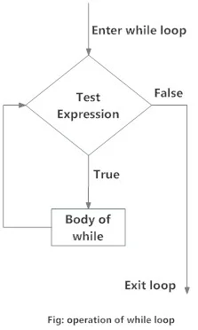

```python
count = 0 # Initializing, To Give an initial value to a variable
while count<10: # Setting a condition
  print(count)
  count+=2 # Incrementing the initial value by 2
```

```
## 0
## 2
## 4
## 6
## 8
```

In the example, the while statement checks if count is less than 10.

**Initially**, count is zero so the statement is true and it executes the body of while. Then the count gets incremented by 2. Again we check the condition and this goes on till the condition becomes false.

Here, when our code checks 10<10, the statement returns False and so the code in while block is not executed.

### Example

```python
# While Loop Example

dates = [1982, 1980, 1973, 2000]

i = 0
year = dates[0]

while(year != 1973):
    print(year)
    i = i + 1
    year = dates[i]
```

```
## 1982
## 1980
```

```python
print("It took ", i ,"repetitions to get out of loop.")
```

```
## It took  2 repetitions to get out of loop.
```

## Infinite loop

A loop is called an infinite loop when the loop will never reach its end.

Usually, when a condition is always True in a while loop, the loop will become an infinite loop. So we should be careful when writing conditions and while updating variables used in the loop.

In Python shell, we can **stop/terminate** the program on an **infinite loop by using CTRL + C**. In jupyter notebook press `i` twice.

*Quick Quiz*: *Write a program to print 1 to 50 using a while loop*.

*Quick Quiz*: *Write a program to print the contents of a `list=['C', 'C++', 'java', 'fortran','python']` using while loop*.

## Loop control statements in Python

[figure not shown]

```python
num = 0
while num<10:
  num +=1
  if num==5:
    break
  print(num)
```

```
## 1
## 2
## 3
## 4
```

In this loop, we are **incrementing** the value of **num variable** and then printing it. When the num value becomes **5** the **break statement** is **executed** which **terminates** the loop and therefore loop is not **executed further**.

```python
num = 0
while num<10:
  num +=1
  if num==5:
    continue
  print(num)
```

```
## 1
## 2
## 3
## 4
## 6
## 7
## 8
## 9
## 10
```

Here, we see that when the **num** variable is equal to **5**, the **continue statement is executed**. It then **doesn’t execute the lines after the continue statement** and the **control** is sent to the **next iteration**.

## Common Mistakes

1. Mostly people forgte to initialize the variable.
2. There is second issue, we might face if we forget to initialize the variables with the right value. we might have already used the variable in our program. if we reuse a variable without setting the correct value from the start, it will still have the value from before.

```python
x=1
sum = 0
while x<10:
  sum+=x
  x+=1
print(sum)
```

```
## 45
```

*Whenever you are writing a loop, check that you are initializing all the variables you want to use before you use them.*

```python
product = 1
x=1
while x<10:
  product=product*x
  x+=1
print(product) # what we call this outcome!
```

```
## 362880
```

## Exercise

1. A list of groceries is given below, print all items with its index.

   ```
   groceries = ["bananas","butter","cheese","toothpaste"]
   ```

2. Make a combination of all the letters of ‘SBP’ and ‘NIBAF’
3. Write a program to say “hello” to all persons in a list which starts with M. `List = ['Ahmad', 'Muhammad', 'Essa', 'Mossa']`
4. Print odd numbers in first 10 numbers using while loop.
5. Also find the sum of all numbers in above question.
6. Write a program to print the multiplication table of a number entered by the user, using **‘for’ loop.**
7. Attempt above problem using while loop.
8. Find the total of `[10,20,30]` using for loop.
9. Write a program to guess a secrete number in 3 attempts using while loop.
10. Solve above problem while generating secrete number randomly.
11. Provide a hint to make problem easy, if guess is larger, then print ‘its larger’, otherwise ‘its smaller’
12. Write a program whether a given number is prime or not.
13. Find the prime numbers in a given range.
14. store the numbers obtained in above question as a list.
15. Find the sum of all the numbers in the list above in question 14.
16. Challenge: calculate the time required to run the above code 500 times.
17. Draw the following pattern using nested loop.

    ```python
    #    xxxxx
    #    xx
    #    xxxxx
    #    xx
    #    xx
    ```

18. Make the co-ordinates (0,0,0) …(2,2,2) using nested for loop.
19. Write a `for` loop the prints out all the element between **-5** and **5** using the range function.
20. Write a while loop to display the values of the Rating of an album playlist stored in the list `PlayListRatings`. If the score is less than 6, exit the loop. The list `PlayListRatings` is given by: `PlayListRatings = [10, 9.5, 10, 8, 7.5, 5, 10, 10]`
21. Write a program to sum first n natural numbers, take input from user.
22. Write program to find the factorial of a number n.
23. Write a program to print the following pattern.

    ```
    *
    * *
    * * *
    * * * *
    * * * * *
    ```

24. Write a Python program to concatenate all elements in a list into a string and return it
25. Write a nested `for` loop program to print multiplication table in Python from 2 to 10.
26. Write a Python program to print all even numbers from a given numbers list in the same order and stop the printing if any numbers that come after 237 in the sequence.

    ```python
    numbers = [386, 462, 47, 418, 907, 344, 236, 375, 823, 566, 597, 978, 328, 615, 953, 345, 399, 162, 758, 219, 918, 237, 412, 566, 826, 248, 866, 950, 626, 949, 687, 217, 815, 67, 104, 58, 512, 24, 892, 894, 767, 553, 81, 379, 843, 831, 445, 742, 717, 958,743, 527]
    ```

27. Write a program to find those numbers which are divisible by 7 and multiple of 5, between 1500 and 2700 (both included) and print the result in the form of a list.

# Functions and Recursion

## Function

A function is a group of related statements that performs a specific task.

Functions help break our program into smaller and modular chunks. As our program grows larger and larger, functions make it more organized and manageable. Furthermore, it avoids repetition and makes the code reusable any number of time.

### Syntax

```python
def function_name(parameters):
    """docstring"""
    statement(s)
```

Above shown is a function definition that consists of the following components.

- Keyword **`def`** that marks the start of the function header.
- A function name to uniquely identify the function. Function naming follows the same rules of writing identifiers in Python.
- Parameters (`arguments`) through which we pass values to a function. They are optional.
- A colon (:) to mark the end of the function header.
- Optional documentation string (doc string) to describe what the function does.
- One or more valid python statements that make up the function body. Statements must have the same indentation level (usually 4 spaces).
- The statement `return` exits a function, optionally passing back a value..

### Example

```python
def greet(name):
  '''Greeting Function'''
  print("Good Day, " +name)
greet("Ahmad")
```

```
## Good Day, Ahmad
```

### Quick Quiz

1. `Define a function to say Hello, good morning "name", if the person in your contact list, otherwise ask "Who are You?".`
2. `Define a function to return the absolute value of the entered number.`

## Type of functions

Basically, we can divide functions into the following two types:

1. `Built-in functions` - Functions that are built into Python.
2. `User-defined functions` - Functions defined by the users themselves.

For example, len( ), range ( ) and print( ) are `built-in functions`, and the `greet function` defined above is a `user-defined function`.

## Functions with arguments

```python
def greet1(name,msg):
  print("Hello", name +', '+msg)
greet1('ahmad', 'how are you')
```

```
## Hello ahmad, how are you
```

Here, the function `greet1()` has two parameters.

Since we have called this function with two arguments, it runs smoothly and we do not get any error.

If we call it with a different number of arguments, the interpreter will show an error message. Below is a call to this function with one and no arguments along with their respective error messages.

```python
def greet1(name,msg):
  print("Hello", name +', '+msg)
greet1('ahmad')
```

```
## Error in py_call_impl(callable, dots$args, dots$keywords): TypeError: greet1() missing 1 required positional argument: 'msg'
##
## Detailed traceback:
##   File "<string>", line 1, in <module>
```

## Default argument or parameter value

Function **arguments** can have **default values** in Python. We can provide a default value to an argument by **using the assignment operator (=)**. Here is an example.

```python
def greet1(name ,msg="How do you do"):
  print("Hello", name +', '+msg)
greet1('Ahmad')
```

```
## Hello Ahmad, How do you do
```

The input to a function is called a formal parameter.

A variable that is declared inside a function is called a **local variable**. The parameter only exists within the function (i.e. the point where the function starts and stops).

A variable that is declared outside a function definition is a global variable, and its value is accessible and modifiable throughout the program.

```python
def square(a): # formal parameter
  '''
  This function will return the sqaure of number plus 1

  '''
  b = 1 # local variable
  c = a*a + b
  return c

print(square(2))
```

```
## 5
```

## Recursive function

Recursion is the process of defining something in terms of itself. That is, a function that calls itself. For example:

`factorial(n)=n * factorial(n-1)`

### Example:

```python
#n! = 1*2*3*...*n
n=3
product = 1
for i in range(n):
  product=product*(i+1)
print(product)
```

```
## 6
```

### Return Values

The Python return statement is a **special statement that you can use inside a function or method to send the function’s result back to the caller**. To let a function return a value, use the return statement:

above example can be wrapped in a function as:

```python
def fact(n):
  product = 1
  for i in range(n):
    product=product*(i+1)
  return product
print(fact(3))
```

```
## 6
```

Using Recursion

```python
#num = input("Enter a number: ")
num=3
def recur_factorial(n):
   if n == 1:
       return n
   elif n < 1:
       return ("NA")
   else:
       return n*recur_factorial(n-1)

print (recur_factorial(int(num)))
```

```
## 6
```

## Pre-defined Functions

There are many pre-defined functions in Python, so let’s start with the simple ones.

The `print()` function:

```python
# Build-in function print()

list1 = [10.0, 8.5, 9.5, 7.0, 7.0, 9.5, 9.0, 9.5]
print(list1)
```

```
## [10.0, 8.5, 9.5, 7.0, 7.0, 9.5, 9.0, 9.5]
```

The `sum()` function adds all the elements in a list or tuple: try pease

The `len()` function show the length a list or tuple: try please

## Exceptions

An exception is an error that occurs during the execution of code. This error causes the code to raise an exception and if not prepared to handle it will halt the execution of the code.

### Exampls

Run each piece of code and observe the exception raised

```python
1/0
```

```
## Error in py_call_impl(callable, dots$args, dots$keywords): ZeroDivisionError: division by zero
##
## Detailed traceback:
##   File "<string>", line 1, in <module>
```

```python
y = a+5
```

```
## Error in py_call_impl(callable, dots$args, dots$keywords): TypeError: unsupported operand type(s) for +: 'set' and 'int'
##
## Detailed traceback:
##   File "<string>", line 1, in <module>
```

```python
a = [1,2,3]
a[5]
```

```
## Error in py_call_impl(callable, dots$args, dots$keywords): IndexError: list index out of range
##
## Detailed traceback:
##   File "<string>", line 1, in <module>
```

## Exercise_Functions

1. Create a function `con` that add two number .
2. Can the `con` function we defined before be used to concatenate lists or tuples?
3. Come up with a function that divides the first input by the second input.
4. Define a function to find the greatest of three numbers using.
5. How do you prevent python print( ) function to print a new line at the end.
6. Write a recursive function to calculate the sum of first n natural numbers.
7. Write a function to print first n lines of the following pattern.  
   *****  
   ***  
   *
8. Write a function which converts inches in cm
9. Write a function to remove a given word from a string and strip it at the same time.
10. Write a Python function to sum all the numbers in a list. Sample List : (8, 2, 3, 0, 7)
11. Write a Python function that takes a list and returns a new list with unique elements of the first list. Sample List :
    $$1,2,3,3,3,3,4,5$$
    , Unique List :
    $$1, 2, 3, 4, 5$$
12. Write a Python function to check whether a number is perfect or not.

    According to Wikipedia : In number theory, a perfect number is a positive integer that is equal to the sum of its proper positive divisors, that is, the sum of its positive divisors excluding the number itself (also known as its aliquot sum). Equivalently, a perfect number is a number that is half the sum of all of its positive divisors (including itself).

    Example : The first perfect number is 6, because 1, 2, and 3 are its proper positive divisors, and 1 + 2 + 3 = 6. Equivalently, the number 6 is equal to half the sum of all its positive divisors : ( 1 + 2 + 3 + 6 ) / 2 =6.
13. Write a function which is capable of addition, subtraction, division and multiplication of two numbers.

**Solution! (Click to expand)**

```python
#num = input("Enter a number: ")
num=3
def recur_factorial(n):
   if n == 1:
       return n
   elif n < 1:
       return ("NA")
   else:
       return n*recur_factorial(n-1)

print (recur_factorial(int(num)))
```

```
## 6
```